# Proyecto AED

Introducción a la Ciencia de Datos. Máster en Ciencia de Datos- UV

Rubén Sánchez Munuera, Luis Molina Villar y Pablo Gallart Carbonell

2026-10-25

# 1 Introducción del trabajo

# 2 Introducción

Este documento explicativo te puede servir de plantilla para la realización de proyectos con *Rmarkdown* para la realizacón de memorias de práctica, tareas, etc. Pretende ser autoexplicativo.

# 3 Estructura del fichero

El bloque inicial separado entre 3 guiones, se denomina cabecera YALM y determina el formato y tipo de documento generado Las opciones dependen del tipo de documento. Un documento que te ayudará a opciones más complejas lo puedes encontrar en este enlace https://bookdown.org/yihui/rmarkdown/

**NOTA**: Los espacios iniciales son imprescindibles. El documento debe empezar por los guiones (no puede haber comentarios previos)

**title**: “Pon un título a tu documento”  
**subtitle**: Tratamiento de Datos. Grado en Ciencia de Datos- UV  
**author**: “Pon aquí tu nombre y apellidos”

Pone la fecha de generación del documento

**date**: “2026-10-25” Pondría la fecha del día actual. También se puede poner fija “01/02/2021”

Cambio de idioma para que en lugar de “Contents” ponga “Indice” al incluir la tabla de contenido

**params**: **lang**: ES  
**lang**: “es-ES”

En este ejemplo, por defecto se generará una salida html, que es la que está descomentada. Si si quieres otras salidas o varias de ellas descomenta lo que proceda

**output:** Salida(s) generadas

*Salida pdf**. Si se incluye código en LaTeX necesitarás tener instalado un compilador de Latex*

**pdf_document**:  
**toc**: yes Tabla de contenido (índice)  
**toc_depth**: 3 Número de niveles de la tabla de contenido (índice) # 1, ##2,###3  
**number_sections**: yes Numeración de las secciones

Salida html_document:  
**echo**: yes **number_sections**: yes  
**theme**: lumen Aspecto y estilo. Otras opciones: *cerulean, journal, flatly, darkly, readable, spacelab, united, cosmo, lumen, paper, sandstone, simplex, and yeti*  
**toc**: yes

*Salida html_notebook**, como html, pero con algunas opciones de visualización*

**bookdown::html_document2:** Versión enriquecida de html que permite numerar figuras, referenciar, etc. https://bookdown.org/yihui/bookdown/ **bookdown::pdf_document2:** Versión enriquecida de pdf que permite numerar figuras, referenciar, etc.

Las opciones siguientes nos permiten traducir estas etiquetas para que aparezcan en otro idioma en caso de que se usen en el documento para referenciar a figuras, tablas, etc.

**language:**  
**label:** **fig:** ‘Figura’  
**tab:** ‘Tabla’  
**eq:** ‘Ecuación’  
**thm:** ‘Teorema’  
**lem:** ‘Lema’  
**def:** ‘Definición’  
**cor:** ‘Corolario’  
**prp:** ‘Proposición’  
**exm:** ‘Ejemplo’  
**exr:** ‘Ejercicio’  
**proof:** ‘Demostración.’  
**remark:** ‘Nota:’  
**solution:** ‘Solución.’

# 4 Configuración del los bloques (*Chunks*)

Cada bloque tiene muchos parámetros que pueden ser configurados

**eval** = **FALSE** evita que el código se ejecute.

**include** = **FALSE** evita que el código y los resultados aparezcan en el archivo terminado. R Markdown aún ejecuta el código en el fragmento y los resultados pueden ser utilizados por otros fragmentos.

**echo = FALSE** evita que el código, pero no los resultados, aparezcan en el archivo terminado. Esta es una manera útil de incrustar figuras.

**message = FALSE** evita que los mensajes generados por el código aparezcan en el archivo finalizado.

**warning = FALSE** evita que las advertencias generadas por el código aparezcan en el final.

**fig.cap = “…”** agrega un título a los resultados gráficos.

Se pueden especificicar opciones generales por defecto en *opts_chunk$set*

Más opciones en el enlace [<https://bookdown.org/yihui/rmarkdown/>](https://bookdown.org/yihui/rmarkdown/)

# 5 Instalación automática de paquetes

Especificar las librerías necesarias para ejecutar el código en la variable *packages*. Si no está instaladas, se instalarán y cargarán (solo para aquellas que están en el repositorio http://cran.rediris.es)

El siguiente bloque, al no especificar opciones del *chunk* usa la configuración por defecto.

```
# Asegúrate que el paquete "pacman" está instalado
if (!require("pacman")) install.packages("pacman")
```

Utilizaremos la librería `pacman` (package manager) para gestionar la instalación de librerías. Es necesario que dicha librería esté instalada previamente.

https://epirhandbook.com/es/suggested-packages-1.html

Utilizamos la función `p_load` para la carga e instalación de paquetes

```
pacman::p_load(
     bookdown,
     rio      # importación/exportación de múltiples tipos de datos
     )
```

# 6 Trabaja con proyectos.

https://epirhandbook.com/es/r-projects.html

Para cada tarea crea un nuevo proyecto con, al menos, una carpeta *./data*, que contenga los datos (puedes usar carpetas adicionales para organizar la información **./program, /figuras**, etc). (La carpeta donde se encuentra este fichero es un proyecto)

# 7 Introducción del trabajo

Haz un breve introducción indicando el contenido del documento:

## 7.1 Subapartado (nivel 2 ##). Rutas locales

Usa rutas referidas a la carpeta en la que se encuentra el fichero fuente, y siempre rutas **relativas** a dicha ubicación. Ejemplos

**ruta1<-‘data/tabla1.txt’** : el fichero está en la carpeta datos que cuelga del directorio donde está el código.

**ruta2<-‘./data/tabla1.txt’** : el fichero está en la carpeta datos que cuelga de un nivel superior

**ruta3<-‘../data/tabla1.txt’** : el fichero está en la carpeta datos que cuelga del nivel superior

**ruta4<-‘./../data/tabla1.txt’** : igual a la anterior

**ruta4<-‘../../data/tabla1.txt’** : el fichero está en la carpeta datos que cuelga de dos niveles superiores

ruta5<-‘C:/MisDatos/Ej.txt’ **NO USAR NUNCA UNA RUTA ABSOLUTA COMO ESTA**

### 7.1.1 Subsubapartado (nivel 3 ###). Cómo incluir figuras

Podemos especificar parámetros de tamaño y ubicación en el *chunk*

### 7.1.2 Subsubapartado (nivel 3 ###).

```r
#knitr::include_graphics("figure/logoEtse.png")
```

# 8 Inclusión de ecuaciones

Puedes incluir expresiones matemáticas usando la nomenclatura LaTeX por ejemplo:

$ax^2+bx+c=0$

### 8.0.1 Subsubapartado (nivel 3 ###).

Podemos referirnos a una figura haciendo referencia al nombre del chunk `\@ref(fig:chunk-name))`

```r
#hist(rnorm(100000),breaks=100)
```

# 9 Nuevo apartado nivel I #

Compila el proyecto como **pdf** y como **html** y observa el fichero obtenido. Cuando generes el documento **html**, observa el efecto de cambiar el valor **theme** por algún otro. Ten en cuenta que este parámetro solo se puede usar la salida **html**.

## 9.1 PASO 1: EXTRACCIÓN Y LIMPIEZA DEL PIB PER CÁPITA (2022-EFECTO COVID 2020-2021)

Justificación Metodológica: Selección del año 2022 como corte transversal

Para la realización de este análisis (MVP) y la contrastación de nuestra hipótesis sobre el impacto del sector servicios en el mercado inmobiliario, se ha optado por realizar un análisis de corte transversal (cross-sectional) centrado en el ejercicio fiscal 2022. Esta decisión metodológica se fundamenta en tres criterios operativos:

Efecto estabilizador post-pandemia: Los años 2020 y 2021 presentan anomalías extremas en la Contabilidad Regional debido a las restricciones de movilidad y la paralización de la hostelería derivadas de la COVID-19. Incluir estos años distorsionaría el análisis estructural de las provincias dependientes del turismo. 2022 representa el primer ejercicio de reactivación económica normalizada.

Consolidación estadística: En las series publicadas por el Instituto Nacional de Estadística (INE), los datos correspondientes a 2023 y 2024 figuran bajo las etiquetas de “Avance (A)” o “Provisional (P)”. El año 2022 garantiza el uso de cifras definitivas y consolidadas tanto en el PIB como en el Valor Añadido Bruto sectorial.

Claridad analítica y espacial: Dada la limitación de extensión del informe, un análisis de corte transversal permite generar visualizaciones bivariantes nítidas (diagramas de dispersión de 52 observaciones) que demuestran la correlación estructural actual, evitando el solapamiento o “ruido” visual que generaría la representación de series temporales completas.

```r
# Cargar librerías necesarias
library(tidyverse)
library(rio)
library(janitor)
library(stringr)

# 1.1 Leer el archivo en crudo, sin asumir cabeceras, desde la fila donde empiezan los datos (fila 7)
pib_raw <- import("datosPablo/pr_cre_26.xls", sheet = "Tabla_2", skip = 6, col_names = FALSE)

# 1.2 Extraer solo las columnas que nos interesan.
# Al inspeccionar el Excel, sabemos que la columna 2 es el Territorio y la columna 90 es el "Valor" del año 2022.
pib_step1 <- pib_raw %>%
  select(
    Territorio = 1,
    PIB_per_capita = 89
  ) %>%
  filter(!is.na(Territorio)) # Quitamos filas vacías del final del Excel

# 1.3 Aislar exclusivamente las 52 provincias/ciudades autónomas
# Definimos la lista de Comunidades Pluriprovinciales y Total que hay que borrar
ccaa_a_borrar <- c("ANDALUCÍA", "ARAGÓN", "CANARIAS", "CASTILLA Y LEÓN",
                   "CASTILLA - LA MANCHA", "CATALUÑA", "COMUNITAT VALENCIANA",
                   "EXTREMADURA", "GALICIA", "PAÍS VASCO", "TOTAL NACIONAL")

pib_clean <- pib_step1 %>%
  mutate(Territorio = str_trim(Territorio)) %>%
  # Quitamos las comunidades pluriprovinciales y totales
  filter(!toupper(Territorio) %in% ccaa_a_borrar) %>%
  # Quitamos agregados de "ESPAÑA" por si acaso
  filter(!grepl("ESPAÑA", toupper(Territorio))) %>%
  # Quitamos las notas al pie del Excel (empiezan por guion, paréntesis, o la palabra Nota/Volver)
  filter(!grepl("^-|^\\(|^Nota|^Volver", Territorio)) %>%
  # Renombramos y convertimos a numérico
  mutate(
    Provincia = case_match(
      Territorio,
      "ASTURIAS, PRINCIPADO DE"      ~ "Asturias",
      "BALEARS, ILLES"               ~ "Balears, Illes",
      "CANTABRIA"                    ~ "Cantabria",
      "MADRID, COMUNIDAD DE"         ~ "Madrid",
      "MURCIA, REGIÓN DE"            ~ "Murcia",
      "NAVARRA, COMUNIDAD FORAL DE"  ~ "Navarra",
      "RIOJA, LA"                    ~ "Rioja, La",
      "CEUTA"                        ~ "Ceuta",
      "MELILLA"                      ~ "Melilla",
      .default = Territorio          # el resto se queda igual
    ),
    PIB_per_capita = as.numeric(PIB_per_capita)
  ) %>%
  select(Provincia, PIB_per_capita)

# 1.4 Verificación
print(paste("Total de provincias extraídas:", nrow(pib_clean)))
```

```
[1] "Total de provincias extraídas: 52"
```

```r
head(pib_clean)
```

```
  Provincia PIB_per_capita
1   Almería          22098
2     Cádiz          20644
3   Córdoba          20022
4   Granada          20624
5    Huelva          24145
6      Jaén          18859
```

## 9.2 PASO 2: ESTRUCTURA PRODUCTIVA (VAB por Sectores)

El archivo original del INE presenta una estructura orientada a la visualización humana, mezclando dos niveles jerárquicos distintos en la misma columna.En la columna principal se intercala el nombre de la provincia (ej. “02 Albacete”) con celdas de datos vacías, seguido en las filas inferiores de los sectores productivos (ej. “A. Agricultura”) con sus valores correspondientes. Si importamos esto de forma directa, la conexión relacional entre cada sector y su provincia se perdería, invalidando el análisis. Para resolverlo con rigor metodológico, aplicamos una técnica de reestructuración (Data Wrangling): 1. Condicional `if_else` + regex: Detecta códigos numéricos iniciales para identificar qué filas actúan como “Cabecera de Provincia”. 2. Función `fill(.direction = "down")`: Arrastra (rellena hacia abajo) el nombre de la provincia detectada hacia todas las filas de sus sectores. 3. Expresiones regulares: Simplifican la verbosidad de los nombres sectoriales. 4. Pivotaje (Wider): Transforma la estructura a un formato Tidy, donde cada provincia es una fila única y cada sector una variable (columna).

```
[1] "Provincias con datos VAB extraídas: 52"
```

```
# A tibble: 6 × 3
  Provincia        pct_industria pct_servicios_turismo
  <chr>                    <dbl>                 <dbl>
1 Albacete                 12.0                   21.6
2 Alicante/Alacant         10.2                   29.7
3 Almería                   4.35                  29.1
4 Araba/Álava              29.4                   19.0
5 Asturias                 14.4                   23.2
6 Ávila                     8.84                  22.3
```

## 9.3 PASO 3: PRECIO MEDIO DE LA VIVIENDA (AÑO 2022)

Los archivos de transacciones inmobiliarias del INE (34020150…csv) presentan dos complejidades técnicas importantes que debemos resolver con rigor analítico:

Estructura trimestral vs. Anual: El archivo desglosa el precio medio por cada trimestre (T1, T2, T3, T4) para cada año. Para cruzarlo con el PIB y el VAB (que son anuales en el año 2022), no podemos coger un único trimestre al azar, ya que introduciría un sesgo estacional (por ejemplo, el precio en zonas turísticas varía mucho entre verano e invierno). Lo metodológicamente riguroso es calcular la media aritmética de los cuatro trimestres del año 2022 para obtener el precio medio anual representativo.

Formato numérico español: Los valores monetarios vienen en formato de texto con puntos para los miles y comas para los decimales (ej. “183.747,9”). Si R o Python lo leen tal cual, lo interpretarán como carácter. Debemos limpiar las cadenas de texto y convertirlas a formato numérico continuo (numeric).

```
[1] "Provincias con precios de vivienda extraídas: 52"
```

```
  Provincia Valor_Vivienda_2022
1   Almería           108259.35
2     Cádiz           156164.98
3   Córdoba           105750.35
4   Granada           121953.60
5    Huelva           110131.08
6      Jaén            81786.15
```

## 9.4 PASO 4: FUSIÓN MAESTRA Y CREACIÓN DEL ÍNDICE DE PRESIÓN INMOBILIARIA

```
[1] "Top 10 Provincias con mayor Presión Inmobiliaria (Vivienda/PIB):"
```

```
                Provincia PIB_per_capita pct_industria pct_servicios_turismo Valor_Vivienda_2022
1          Balears, Illes          31030     2.5273482              37.08938            402810.9
2                  Málaga          21470     3.2640852              29.08155            275158.8
3  Santa Cruz de Tenerife          22108     2.6094683              32.14867            178236.5
4                 Melilla          19433     0.9561733              19.30092            154902.8
5             Palmas, Las          22358     3.0594661              36.08142            171641.1
6                  Madrid          39246     5.5280990              33.60604            297801.3
7                   Cádiz          20644     8.5702232              23.51378            156165.0
8                   Ceuta          21273     1.5197995              21.70904            160747.2
9                Gipuzkoa          36374    24.8264971              22.84592            263246.3
10              Barcelona          33270    15.1557517              28.99266            237844.1
   presion_inmobiliaria
1             12.981339
2             12.815968
3              8.062083
4              7.971121
5              7.676944
6              7.588068
7              7.564666
8              7.556397
9              7.237210
10             7.148907
```

## 9.5 PASO 5: VISUALIZACIÓN DE “EL ESPEJISMO DEL PIB” (SCATTER PLOT)

Vamos a enfrentar la riqueza (Eje X) contra el coste de la vivienda (Eje Y), y vamos a colorear los puntos según su dependencia del Sector Servicios/Turismo.

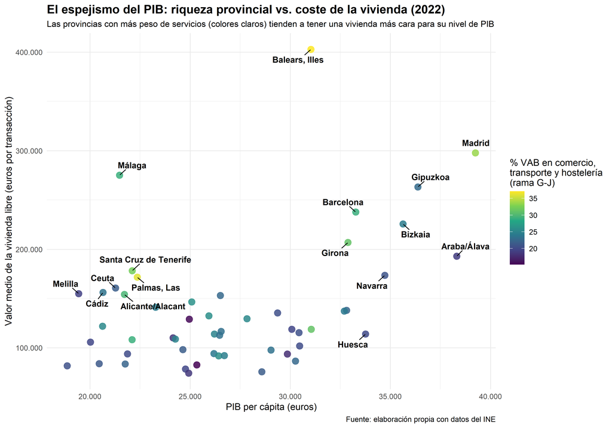

## 9.6 CONLCUSIONES

El análisis bivariante realizado revela una desconexión estructural entre la riqueza real generada en cada provincia (PIB per cápita) y el coste de acceso a la vivienda, evidenciando lo que hemos denominado “el espejismo del PIB”. Como se observa en la gráfica, provincias con una fuerte dependencia del sector servicios y el turismo —tales como Illes Balears, Málaga, Santa Cruz de Tenerife o Alicante— presentan precios inmobiliarios desproporcionadamente altos en comparación con su nivel de renta local. Por el contrario, regiones con mayor peso industrial (como Araba/Álava, Bizkaia o Burgos) mantienen una relación mucho más equilibrada entre los ingresos de sus ciudadanos y el coste de las transacciones inmobiliarias.

Este fenómeno se explica por la naturaleza del modelo productivo basado en la tercerización y el turismo. Este modelo tiende a atraer una fuerte demanda externa (inversores extranjeros, segundas residencias, nómadas digitales y pisos turísticos) que compite directamente por el suelo y la vivienda con la población residente. En consecuencia, los precios del mercado inmobiliario se inflan impulsados por capital foráneo, desvinculándose por completo de la capacidad adquisitiva real del territorio.

En definitiva, la estructura productiva condiciona severamente la presión inmobiliaria. Dado que los salarios medios en la hostelería y los servicios de bajo valor añadido suelen ser inferiores a los del sector industrial, se produce una brecha insalvable: el mercado de la vivienda opera bajo lógicas de precios internacionales o especulativos, mientras que los ciudadanos compiten con salarios locales mermados. Esto confirma nuestra hipótesis inicial de que no basta con analizar el crecimiento del PIB de forma aislada; es fundamental comprender de qué sectores proviene dicha riqueza para entender la verdadera salud económica y social de una provincia.